# Censoring MLE Simulation

Haddon Sandefur

2022-09-19

Hey there, my name is Haddon (I also go by Josh). This webpage is my first attempt at publishing an html document online! If you’re reading this, it means that my efforts worked. Since publishing a webpage that says “test this, test that…” is boring, I have attached the below Survival Analysis simulation problem (coded in R) to the page to give it some personality. Feel free to check it out!

### Problem

This problem is motivated by a homework assignment I received as a graduate student at Duke University. It is outlined as follows:

Let event time be defined by $X\space \sim \space Exp(\lambda)$ and censoring time $Y\space \sim \space Exp(\mu)$.

We have two types of data:

Right censoring data, generated by $Z_i\space = \space min(X_i, Y_i)$ and $\Delta_i\space=\space 1[X_i\le Y_i]$ for $i = 1,2,...,n$

Current status, interval censored data generated by $Z_i\space = \space Y_i$ and $\Delta_i\space=\space 1[X_i\le Y_i]$ for $i = 1,2,...,n$

(Monte-Carlo simulation experiment) Consider a Monte-Carlo simulation study to compare the two MLEs under the following setting:

• Choose the true parameter $\lambda$ = 5

• Choose the parameter $\mu$ according to the censoring rate $CP=Pr(X > Y)$

• Generate $n$ independent paired observations $(x_i; y_i), \space i = 1, 2, ..., n$

• Construct right censored data and current status data, respectively, from the paired observations

• Find the two MLEs of $\lambda$ corresponding to each of the censored data

• Repeat this process for 1000 times, so that you can calculate the sample bias and standard deviation

You are required to conduct this experiment with each of the three censoring parameters:

CP=0.1 (light censoring); CP=0.5 (moderate censoring); CP=0.9 (heavy censoring) and with three different sample sizes: n=100, 200, 400.

Note that the $\mu$s chosen for the different censoring probabilities correspond to a previous problem out of the scope of this webpage.

### Solution

This following chunk contains expressions of the log-likelihood, score, first derivative of the score, and sample size from an exponential density (The density of Event Time X) with a censoring indicator factored into the likelihood.

```r
#Math to Code Expression for this Particular Likelihood:
f.exp_int <- function(z, Status, lambda){
  n <- length(z)
  loglik <- expression(-lambda*z+Status*log(exp(lambda*z)-1))
  U <- -z+(Status*z*exp(lambda*z)/(exp(lambda*z)-1))
  dU <- -(Status*(z^2)*exp(lambda*z))/(exp(lambda*z)-1)^2
  return(list(loglik=loglik, U=sum(U), dU=sum(dU)))
}
```

The function for the Newton-Raphson Algorithm is below. This algorithm is our numerical method for obtaining the Maximum Likelihood Estimate for current status data. The MLE for right censored data is defined in the simulation process later, but does not utilize the Newton-Raphson Algorithm in this circumstance (rather, we use the theoretical expression).

```r
#Newton-Raphson Algorith Function
NR_Estimate <- function(z, indicator, lambda_0,m){

  tmp.iter <- NULL

  for(l in 1:m){
    one <- f.exp_int(z = z, Status = indicator, lambda = lambda_0)
    tmp.iter <- rbind(tmp.iter, c(lambda = lambda_0, U = one$U, dU =one$dU))
    lambda_0 <- lambda_0 - one$U/one$dU
  }
  return(list(sequence = tmp.iter, MLE = tmp.iter[nrow(tmp.iter)]))
}
```

The simulation to obtain our MLE estimates is below:

```r
#==========================The Simulation================================
# k the number of MLEs we want to calculate, each iteration corresponding to a sample of size n.

# n is the sample size of the event time random variable and the censoring random variable from respecitive exponential densities

# mu_r is the rate parameter for the exponential density, which we'll apply to the censoring randomc variable.

# m is the number of iterations in the NR Algorithm from the previous chunk.

cens_sim <- function(k,n,mu_r,m){

  # Empty Matrix to Store MLEs in.
  MLE_Sample <- matrix(data = NA, nrow = k, ncol = 2)

  # Master Loop: Generates and Stores an MLE of Generated Data
  for(j in 1:k){


    #Data Generation Loop
    for(i in 1:n){

      ev_time <- NULL
      censor <- NULL

      #Generating Event Time and Censored Data with below densities.

      ev_time <- rexp(n, rate = 5)
      censor <- rexp(n, rate = mu_r)
    }


    #Right Censoring Data: Storing and Creating Indicator (Status) Variable
    z <- cbind(ev_time, censor)
    z <- as.data.frame(z)
    z <- z %>%
      mutate(Status = ifelse(ev_time <= censor, 1, 0), #Indicator Variable,
             z = ifelse(ev_time <= censor, ev_time, censor))  %>%
      select(z, Status)

    #Current Status Data (Type of Interval Censored Data)
    z2 <- cbind(ev_time, censor)
    z2 <- as.data.frame(z2)
    z2 <- z2 %>%
      mutate(Status = ifelse(ev_time <= censor, 1, 0)) %>%
      select(censor, Status) # Here we only know status at observation...
                             # so effectively all data is censored.

    # Here, the column name "censored" is being renamed to "z"
    # Again, the censored data arose from the "censor" pdf. So all "z" is censored here.

    colnames(z2) <- c("z", "Status")

    # The MLE for the Right Censored Data (This is the aforementioned Theoretical Expression)

    MLE1 <- sum(z$Status)/sum(z$z)

    # MLE for Current Status Data
    MLE2 <- NR_Estimate(z2$z, indicator = z2$Status, lambda_0 =  5, m = m)$MLE



    #Right Censored MLE Storing
    MLE_Sample[j,1] <- MLE1

    #Current Status MLE Storing
    MLE_Sample[j,2] <- MLE2


  }

  # Returning Set of MLEs for each data type.
  return(list(MLE_set = as.data.frame(MLE_Sample)))

}
```

Next we’ll write a couple of functions that return our answers in a nice format.

Right Censoring Answer Function:

```r
#Getting Answers
#===========================================================

#Right Censored answer function
RC_give_answers <- function(mu_r){

  # Storage
  bias <- NULL
  st_d <- NULL
  estimates <- list()

  # Sample sizes from the densities
  sizes <- c(100, 200, 400)

  # Calculate the Mean, SD, and Bias of Generated MLEs of Right Censored Data for each of the Above Sample Sizes. For this function, k = 1000 in the Sim function.
  for(i in 1:3){

    #Bias
    bias[i] <- mean(cens_sim(1000, n = sizes[i], mu_r = mu_r, m = 100)$MLE_set$V1, na.rm = TRUE) - 5

    #Standard Deviation of MLE vector.
    st_d[i] <- sd(cens_sim(1000, n = sizes[i], mu_r = mu_r, m = 100)$MLE_set$V1, na.rm = TRUE)



  }

  # Make Vectors for Printing Bias and Standard Deviation
  bias <- matrix(bias, nrow = 3, ncol = 1)
  st_d <- matrix(st_d, nrow = 3, ncol = 1)

  # Join the above two Vectors
  answers <- cbind(bias, st_d)
  answers <- as.data.frame(answers)

  # Name Columns
  colnames(answers) <- c("Bias", "SD")
  rownames(answers) <- c("100", "200", "400")

  # N=400, k=1000 Vector of MLEs to plot Sampling Distribution with Later:
  estimates <- cens_sim(1000, n = 400, mu_r = mu_r, m = 100)$MLE_set$V1

  # Return Answers
  return(list(answers, bias, st_d, estimates))
}
```

Current Status (Interval Censoring) Function:

```r
# Current Status answer function
IC_give_answers <- function(mu_r){

  # This procedure is the same as above except we select "cens_sim(...)$MLE_set$V2" instead of "cens_sim()$MLE_set$V1"
  bias <- NULL
  st_d <- NULL
  estimates <- NULL
  sizes <- c(100, 200, 400)

  for(i in 1:3){



    bias[i] <- mean(cens_sim(1000, n = sizes[i], mu_r = mu_r, m = 100)$MLE_set$V2, na.rm = TRUE) - 5
    st_d[i] <- sd(cens_sim(1000, n = sizes[i], mu_r = mu_r, m = 100)$MLE_set$V2, na.rm = TRUE)



  }

  bias <- matrix(bias, nrow = 3, ncol = 1)
  st_d <- matrix(st_d, nrow = 3, ncol = 1)

  answers <- cbind(bias, st_d)
  answers <- as.data.frame(answers)
  colnames(answers) <- c("Bias", "SD")
  rownames(answers) <- c("100", "200", "400")

  estimates <- cens_sim(1000, n = 400, mu_r = mu_r, m = 100)$MLE_set$V2

  return(list(answers, bias, st_d, estimates))
}
```

Now Let’s return our answers.

Right Censored Answers:

```r
#Right Censored Answers
set.seed(10)

RC1 <- RC_give_answers(5/9)
RC2 <- RC_give_answers(5)
RC3 <- RC_give_answers(45)


print(c(RC1[1],RC2[1],RC3[1]))
```

```
## [[1]]
##           Bias        SD
## 100 0.06572690 0.5486712
## 200 0.03323233 0.3730461
## 400 0.01368690 0.2645757
##
## [[2]]
##            Bias        SD
## 100 0.047141228 0.7428664
## 200 0.012250648 0.4873193
## 400 0.007776808 0.3563750
##
## [[3]]
##             Bias       SD
## 100 0.0001623492 1.657677
## 200 0.0017091345 1.142186
## 400 0.0070012140 0.824166
```

Current Status Answers:

```r
#Interval Censored Answers
set.seed(10)

IC1 <- IC_give_answers(5/9)
IC2 <- IC_give_answers(5)
IC3 <- IC_give_answers(45)

print(c(IC1[1],IC2[1],IC3[1]))
```

```
## [[1]]
##           Bias        SD
## 100 0.36393528 1.8359575
## 200 0.18941329 0.9022137
## 400 0.05344938 0.5955794
##
## [[2]]
##           Bias        SD
## 100 0.07467354 0.8366567
## 200 0.02215587 0.5660728
## 400 0.01440480 0.3927635
##
## [[3]]
##            Bias        SD
## 100 0.159195098 1.5555160
## 200 0.032717565 1.1206011
## 400 0.009745133 0.8267299
```

I’ll plot some distributions of the generated MLEs (for the n=400 set), with a marker of the true Event Time parameter value (lambda = 5) for the sake of visualization:

First we need to do some data wrangling:

- Grab vectors of MLEs from our answer functions and combine them into a dataframe.
- Transpose this data frame so we can plot one value, faceted by each censoring level.

```r
#Grabbing and combining vectors of MLEs into a single dataframe
plot_data <- as.data.frame(cbind(unlist(RC1[4]),
                                 unlist(RC2[4]),
                                 unlist(RC3[4]),
                                 unlist(IC1[4]),
                                 unlist(IC2[4]),
                                 unlist(IC3[4])
  )
)

#Renaming Columns
colnames(plot_data) <- c("RC1: CP = 0.1",
                         "RC2: CP = 0.5",
                         "RC3: CP = 0.9",
                         "IC1: CP = 0.1",
                         "IC2: CP = 0.5",
                         "IC3: CP = 0.9"
)

#Transposing Dataframe
plot_data_long <- plot_data %>%
  pivot_longer(cols = `RC1: CP = 0.1`:`IC3: CP = 0.9`, values_to = "Simulated Data")
```

Plot

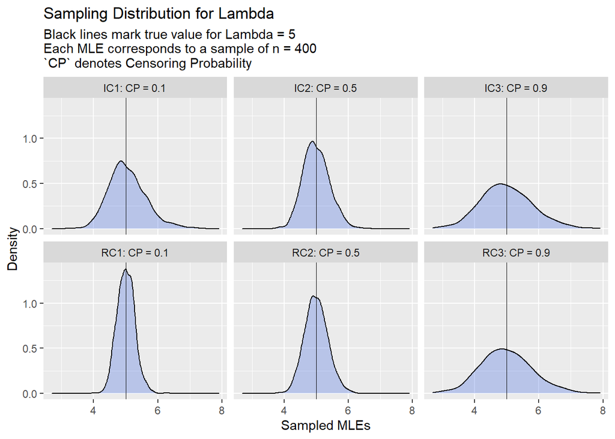

```r
ggplot(data = plot_data_long, aes(x = `Simulated Data`))+
  geom_density(fill = "Royal Blue", alpha=0.3)+
  geom_vline(xintercept = 5, size = .2)+
  labs(title = "Sampling Distribution for Lambda",
       subtitle = "Black lines mark true value for Lambda = 5
Each MLE corresponds to a sample of n = 400
`CP` denotes Censoring Probability ") +
  ylab("Density")+
  xlab("Sampled MLEs")+
  facet_wrap(~name)
```

Here we can see how heavier censoring impacts the sampling distributions for both right and current status censoring.